# Project

## Data Description

The data contains features extracted from the silhouette of vehicles in different angles. Four "Corgie" model vehicles were used for the experiment: a double decker bus, Cheverolet van, Saab 9000 and an Opel Manta 400 cars. This particular combination of vehicles was chosen with the expectation that the bus, van and either one of the cars would be readily distinguishable, but it would be more difficult to distinguish between the cars.

## Domain

Object recognition

## Context

The purpose is to classify a given silhouette as one of three types of vehicle, using a set of features extracted from the silhouette. The vehicle may be viewed from one of many different angles.

## Attribute Information

- All the features are geometric features extracted from the silhouette.
- All are numeric in nature.

## Learning Outcomes

- Exploratory Data Analysis
- Reduce number dimensions in the dataset with minimal information loss
- Train a model using Principle Components

## Objective

Apply dimensionality reduction technique – PCA and train a model using principle components instead of training the model using just the raw data.

### Step 1: Data Pre-processing

```python
# import modules
import numpy as np
import pandas as pd
# data visualization
import matplotlib.pyplot as plt
import seaborn as sns
```

```python
%matplotlib inline
```

```python
# Read data
vehicle = pd.read_csv("vehicle.csv")
```

```python
vehicle.head()
```

|  | compactness | circularity | distance_circularity | radius_ratio | pr.axis_aspect_ratio | max.length_aspect_ratio | scatter_ratio | elongatedness | pr.axis_rectangularity | max.length_rectangularity | scaled_variance | scaled_variance.1 | scaled_radius_of_gyration | scaled_radius_of_gyration.1 | skewness_about | skewness_about.1 | skewness_about.2 | hollows_ratio | class |
| --- | --- | --- | --- | --- | --- | --- | --- | --- | --- | --- | --- | --- | --- | --- | --- | --- | --- | --- | --- |
| 0 | 95 | 48.0 | 83.0 | 178.0 | 72.0 | 10 | 162.0 | 42.0 | 20.0 | 159 | 176.0 | 379.0 | 184.0 | 70.0 | 6.0 | 16.0 | 187.0 | 197 | van |
| 1 | 91 | 41.0 | 84.0 | 141.0 | 57.0 | 9 | 149.0 | 45.0 | 19.0 | 143 | 170.0 | 330.0 | 158.0 | 72.0 | 9.0 | 14.0 | 189.0 | 199 | van |
| 2 | 104 | 50.0 | 106.0 | 209.0 | 66.0 | 10 | 207.0 | 32.0 | 23.0 | 158 | 223.0 | 635.0 | 220.0 | 73.0 | 14.0 | 9.0 | 188.0 | 196 | car |
| 3 | 93 | 41.0 | 82.0 | 159.0 | 63.0 | 9 | 144.0 | 46.0 | 19.0 | 143 | 160.0 | 309.0 | 127.0 | 63.0 | 6.0 | 10.0 | 199.0 | 207 | van |
| 4 | 85 | 44.0 | 70.0 | 205.0 | 103.0 | 52 | 149.0 | 45.0 | 19.0 | 144 | 241.0 | 325.0 | 188.0 | 127.0 | 9.0 | 11.0 | 180.0 | 183 | bus |

```python
# Shape of the data
print("Data has {} samples and {} features".format(vehicle.shape[0],vehicle.shape[1]))
```

```
Data has 846 samples and 19 features
```

```python
# Data types
vehicle.info()
```

```
<class 'pandas.core.frame.DataFrame'>
RangeIndex: 846 entries, 0 to 845
Data columns (total 19 columns):
compactness                    846 non-null int64
circularity                    841 non-null float64
distance_circularity           842 non-null float64
radius_ratio                   840 non-null float64
pr.axis_aspect_ratio           844 non-null float64
max.length_aspect_ratio        846 non-null int64
scatter_ratio                  845 non-null float64
elongatedness                  845 non-null float64
pr.axis_rectangularity         843 non-null float64
max.length_rectangularity      846 non-null int64
scaled_variance                843 non-null float64
scaled_variance.1              844 non-null float64
scaled_radius_of_gyration      844 non-null float64
scaled_radius_of_gyration.1    842 non-null float64
skewness_about                 840 non-null float64
skewness_about.1               845 non-null float64
skewness_about.2               845 non-null float64
hollows_ratio                  846 non-null int64
class                          846 non-null object
dtypes: float64(14), int64(4), object(1)
memory usage: 125.7+ KB
```

Only one column - **`class`** has the data type **`object`** but since it's a categorical column, it can be mapped to integers.

```python
# Describe data
vehicle.describe()
```

|  | compactness | circularity | distance_circularity | radius_ratio | pr.axis_aspect_ratio | max.length_aspect_ratio | scatter_ratio | elongatedness | pr.axis_rectangularity | max.length_rectangularity | scaled_variance | scaled_variance.1 | scaled_radius_of_gyration | scaled_radius_of_gyration.1 | skewness_about | skewness_about.1 | skewness_about.2 | hollows_ratio |
| --- | --- | --- | --- | --- | --- | --- | --- | --- | --- | --- | --- | --- | --- | --- | --- | --- | --- | --- |
| count | 846.000000 | 841.000000 | 842.000000 | 840.000000 | 844.000000 | 846.000000 | 845.000000 | 845.000000 | 843.000000 | 846.000000 | 843.000000 | 844.000000 | 844.000000 | 842.000000 | 840.000000 | 845.000000 | 845.000000 | 846.000000 |
| mean | 93.678487 | 44.828775 | 82.110451 | 168.888095 | 61.678910 | 8.567376 | 168.901775 | 40.933728 | 20.582444 | 147.998818 | 188.631079 | 439.494076 | 174.709716 | 72.447743 | 6.364286 | 12.602367 | 188.919527 | 195.632388 |
| std | 8.234474 | 6.152172 | 15.778292 | 33.520198 | 7.891463 | 4.601217 | 33.214848 | 7.816186 | 2.592933 | 14.515652 | 31.411004 | 176.666903 | 32.584808 | 7.486190 | 4.920649 | 8.936081 | 6.155809 | 7.438797 |
| min | 73.000000 | 33.000000 | 40.000000 | 104.000000 | 47.000000 | 2.000000 | 112.000000 | 26.000000 | 17.000000 | 118.000000 | 130.000000 | 184.000000 | 109.000000 | 59.000000 | 0.000000 | 0.000000 | 176.000000 | 181.000000 |
| 25% | 87.000000 | 40.000000 | 70.000000 | 141.000000 | 57.000000 | 7.000000 | 147.000000 | 33.000000 | 19.000000 | 137.000000 | 167.000000 | 318.000000 | 149.000000 | 67.000000 | 2.000000 | 5.000000 | 184.000000 | 190.250000 |
| 50% | 93.000000 | 44.000000 | 80.000000 | 167.000000 | 61.000000 | 8.000000 | 157.000000 | 43.000000 | 20.000000 | 146.000000 | 179.000000 | 363.500000 | 173.500000 | 71.500000 | 6.000000 | 11.000000 | 188.000000 | 197.000000 |
| 75% | 100.000000 | 49.000000 | 98.000000 | 195.000000 | 65.000000 | 10.000000 | 198.000000 | 46.000000 | 23.000000 | 159.000000 | 217.000000 | 587.000000 | 198.000000 | 75.000000 | 9.000000 | 19.000000 | 193.000000 | 201.000000 |
| max | 119.000000 | 59.000000 | 112.000000 | 333.000000 | 138.000000 | 55.000000 | 265.000000 | 61.000000 | 29.000000 | 188.000000 | 320.000000 | 1018.000000 | 268.000000 | 135.000000 | 22.000000 | 41.000000 | 206.000000 | 211.000000 |

At first glance, **`radius_ratio`**, **`pr.axis_aspect_ratio`**, **`max.length_aspect_ratio`**, **`scaled_variance.1`**, **`scaled_radius_of_gyration.1`**, **`skewness_about`**, **`skewness_about.1`** have some outliers which need further investigation.

Let's start removing these outliers after reviewing them using box plot.

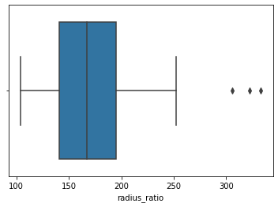

```python
sns.boxplot(vehicle["radius_ratio"])
```

```python
vehicle = vehicle[vehicle["radius_ratio"] <= 300]
```

```python
vehicle.shape
```

```
(837, 19)
```

We lose 9 samples from the above step.

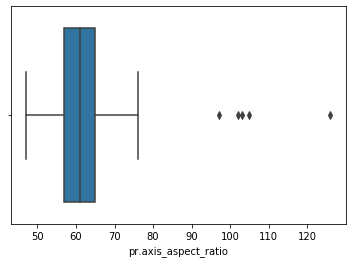

```python
sns.boxplot(vehicle["pr.axis_aspect_ratio"])
```

```python
vehicle = vehicle[vehicle["pr.axis_aspect_ratio"] <= 90]
```

```python
vehicle.shape
```

```
(830, 19)
```

We lose 7 samples from the above step.

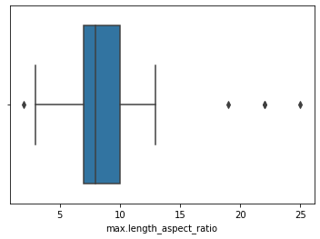

```python
sns.boxplot(vehicle["max.length_aspect_ratio"])
```

In this case, since the minimum value is very close to Q1, I am not removing it.

```python
vehicle = vehicle[vehicle["max.length_aspect_ratio"] <= 15]
```

```python
vehicle.shape
```

```
(826, 19)
```

We lost 4 samples because of the above step.

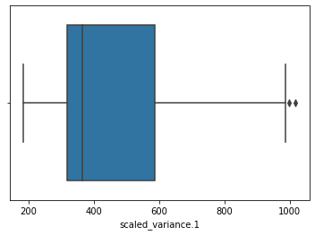

```python
sns.boxplot(vehicle["scaled_variance.1"])
```

There is no need for removing the maximum value in this case.

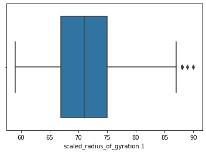

```python
sns.boxplot(vehicle["scaled_radius_of_gyration.1"])
```

There is no need for removing the outliers in the above case.

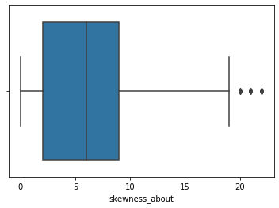

```python
sns.boxplot(vehicle["skewness_about"])
```

Similarly in the above case, the outliers are very close to maximum values and thus should not be removed.

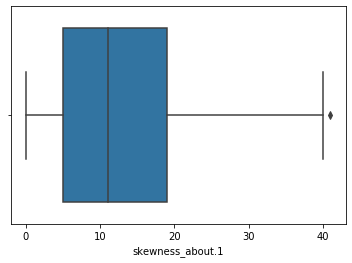

```python
sns.boxplot(vehicle["skewness_about.1"])
```

There is no need for removing the outlier in the above case as well.

```python
vehicle.shape
```

```
(826, 19)
```

We have dropped a total of 20 samples.

```python
20/846 * 100
```

```
2.3640661938534278
```

That means, we have lost around 2.36% of the data.

```python
# Missing values in percentage
vehicle.isna().sum()/len(vehicle.index) * 100
```

```
compactness                    0.000000
circularity                    0.605327
distance_circularity           0.484262
radius_ratio                   0.000000
pr.axis_aspect_ratio           0.000000
max.length_aspect_ratio        0.000000
scatter_ratio                  0.121065
elongatedness                  0.121065
pr.axis_rectangularity         0.363196
max.length_rectangularity      0.000000
scaled_variance                0.363196
scaled_variance.1              0.242131
scaled_radius_of_gyration      0.242131
scaled_radius_of_gyration.1    0.484262
skewness_about                 0.605327
skewness_about.1               0.121065
skewness_about.2               0.121065
hollows_ratio                  0.000000
class                          0.000000
dtype: float64
```

```python
# Columns with missing values
missingCols = vehicle.columns[vehicle.isna().sum()/len(vehicle.index) * 100 != 0]
```

```python
print("Number of columns with missing values: {}".format(len(missingCols)))
```

```
Number of columns with missing values: 12
```

Since we have just **826 samples**, we cannot afford to remove any samples at this stage. We can impute the missing values with the median.

```python
medianFiller = lambda x: x.fillna(x.median())
for col in missingCols:
    vehicle[col].fillna(vehicle[col].median(),inplace=True)
```

```python
# Missing values in percentage
vehicle.isna().sum()/len(vehicle.index) * 100
```

```
compactness                    0.0
circularity                    0.0
distance_circularity           0.0
radius_ratio                   0.0
pr.axis_aspect_ratio           0.0
max.length_aspect_ratio        0.0
scatter_ratio                  0.0
elongatedness                  0.0
pr.axis_rectangularity         0.0
max.length_rectangularity      0.0
scaled_variance                0.0
scaled_variance.1              0.0
scaled_radius_of_gyration      0.0
scaled_radius_of_gyration.1    0.0
skewness_about                 0.0
skewness_about.1               0.0
skewness_about.2               0.0
hollows_ratio                  0.0
class                          0.0
dtype: float64
```

As we can see, there are no missing values now.

Let's finally map the target column - **`class`** to integers as follows.

```python
vehicle["class"].unique()
```

```
array(['van', 'car', 'bus'], dtype=object)
```

```python
vehicle["class"] = vehicle["class"].map({"van":0,"car":1,"bus":2})
```

```python
vehicle.head()
```

|  | compactness | circularity | distance_circularity | radius_ratio | pr.axis_aspect_ratio | max.length_aspect_ratio | scatter_ratio | elongatedness | pr.axis_rectangularity | max.length_rectangularity | scaled_variance | scaled_variance.1 | scaled_radius_of_gyration | scaled_radius_of_gyration.1 | skewness_about | skewness_about.1 | skewness_about.2 | hollows_ratio | class |
| --- | --- | --- | --- | --- | --- | --- | --- | --- | --- | --- | --- | --- | --- | --- | --- | --- | --- | --- | --- |
| 0 | 95 | 48.0 | 83.0 | 178.0 | 72.0 | 10 | 162.0 | 42.0 | 20.0 | 159 | 176.0 | 379.0 | 184.0 | 70.0 | 6.0 | 16.0 | 187.0 | 197 | 0 |
| 1 | 91 | 41.0 | 84.0 | 141.0 | 57.0 | 9 | 149.0 | 45.0 | 19.0 | 143 | 170.0 | 330.0 | 158.0 | 72.0 | 9.0 | 14.0 | 189.0 | 199 | 0 |
| 2 | 104 | 50.0 | 106.0 | 209.0 | 66.0 | 10 | 207.0 | 32.0 | 23.0 | 158 | 223.0 | 635.0 | 220.0 | 73.0 | 14.0 | 9.0 | 188.0 | 196 | 1 |
| 3 | 93 | 41.0 | 82.0 | 159.0 | 63.0 | 9 | 144.0 | 46.0 | 19.0 | 143 | 160.0 | 309.0 | 127.0 | 63.0 | 6.0 | 10.0 | 199.0 | 207 | 0 |
| 5 | 107 | 44.0 | 106.0 | 172.0 | 50.0 | 6 | 255.0 | 26.0 | 28.0 | 169 | 280.0 | 957.0 | 264.0 | 85.0 | 5.0 | 9.0 | 181.0 | 183 | 2 |

We will also standardize the data as the final step.

```python
cols = vehicle.columns
```

```python
cols = cols.drop("class")
```

```python
vehicle[cols] = (vehicle[cols]-vehicle[cols].mean())/(vehicle[cols].std())
```

```python
vehicle.head()
```

|  | compactness | circularity | distance_circularity | radius_ratio | pr.axis_aspect_ratio | max.length_aspect_ratio | scatter_ratio | elongatedness | pr.axis_rectangularity | max.length_rectangularity | scaled_variance | scaled_variance.1 | scaled_radius_of_gyration | scaled_radius_of_gyration.1 | skewness_about | skewness_about.1 | skewness_about.2 | hollows_ratio | class |
| --- | --- | --- | --- | --- | --- | --- | --- | --- | --- | --- | --- | --- | --- | --- | --- | --- | --- | --- | --- |
| 0 | 0.152122 | 0.521408 | 0.056586 | 0.316509 | 1.925877 | 0.904893 | -0.208134 | 0.135427 | -0.225356 | 0.761743 | -0.386459 | -0.342532 | 0.292555 | -0.323349 | -0.075383 | 0.370941 | -0.318642 | 0.175410 | 0 |
| 1 | -0.332089 | -0.614531 | 0.119833 | -0.839874 | -0.733095 | 0.425764 | -0.598312 | 0.517644 | -0.610747 | -0.334901 | -0.580707 | -0.619416 | -0.504667 | -0.009130 | 0.535071 | 0.148269 | 0.005294 | 0.443226 | 0 |
| 2 | 1.241596 | 0.845963 | 1.511276 | 1.285370 | 0.862288 | 0.904893 | 1.142484 | -1.138632 | 0.930818 | 0.693203 | 1.135154 | 1.104051 | 1.396400 | 0.147980 | 1.552495 | -0.408412 | -0.156674 | 0.041502 | 1 |
| 3 | -0.089983 | -0.614531 | -0.006662 | -0.277309 | 0.330494 | 0.425764 | -0.748381 | 0.645050 | -0.610747 | -0.334901 | -0.904455 | -0.738081 | -1.455200 | -1.423117 | -0.075383 | -0.297076 | 1.624976 | 1.514492 | 0 |
| 5 | 1.604754 | -0.127700 | 1.511276 | 0.128987 | -1.973949 | -1.011624 | 2.583143 | -1.903067 | 2.857774 | 1.447146 | 2.980514 | 2.923580 | 2.745544 | 2.033296 | -0.278868 | -0.408412 | -1.290451 | -1.699305 | 2 |

The data is now ready for EDA.

### Step 2: Understanding the attributes

Let's start off with analyzing the correlation between features.

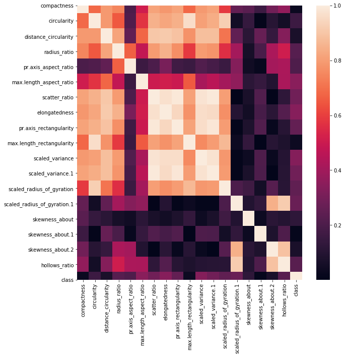

```python
plt.figure(figsize=(10,10))
sns.heatmap(vehicle.corr().abs())
```

**`class`** doesn't have a strong correlation with any of the columns but the following columns are highly correlated with each other and thus, one of them can be removed:

1. **`scaled_radius_of_gyration.1`** and **`hollows_ratio`**
2. **`scaled_radius_of_gyration.1`** and **`skewness_about.2`**
3. **`skewness_about.2`** and **`hollows_ratio`**

The following columns are strongly correlated with a lot of columns and can be removed:

1. **`compactness`**
2. **`circularity`**
3. **`distance_circularity`**
4. **`radius_ratio`**
5. **`scatter_ratio`**
6. **`elongatedness`**
7. **`pr.axis_rectangularity`**
8. **`max.length_rectangularity`**
9. **`scaled_variance`**
10. **`scaled_variance.1`**
11. **`scaled_radius_of_gyration`**

Let's remove all the above 11 columns and **`scaled_radius_of_gyration.1`** and **`skewness_about.2`**.

```python
colsToRemove = ["scaled_radius_of_gyration.1",
               "skewness_about.2",
               "compactness",
                "circularity",
                "distance_circularity",
                "radius_ratio",
                "scatter_ratio",
                "elongatedness",
                "pr.axis_rectangularity",
                "max.length_rectangularity",
                "scaled_variance",
                "scaled_variance.1",
                "scaled_radius_of_gyration"]
```

```python
vehicle_EDA = vehicle.drop(colsToRemove,axis=1)
```

```python
vehicle_EDA.shape
```

```
(826, 6)
```

So, we are now dealing with only 6 columns and 826 samples.

### Step 3: Split the data

```python
from sklearn.model_selection import train_test_split
```

```python
# specify the random state to allow reproducibility
random_state = 42
```

```python
X = vehicle_EDA.drop("class",axis=1)
```

```python
y = vehicle_EDA["class"]
```

Let's carry out a 70:30 split.

```python
X_train, X_test, y_train, y_test = train_test_split(X,y,test_size=0.3,random_state=random_state)
```

```python
X_train.shape
```

```
(578, 5)
```

```python
X_test.shape
```

```
(248, 5)
```

### Step 4: Train a SVM model

```python
from sklearn.svm import SVC
```

```python
model = SVC(kernel="rbf")
```

```python
model.fit(X_train,y_train)
```

```
SVC(C=1.0, cache_size=200, class_weight=None, coef0=0.0,
    decision_function_shape='ovr', degree=3, gamma='auto_deprecated',
    kernel='rbf', max_iter=-1, probability=False, random_state=None,
    shrinking=True, tol=0.001, verbose=False)
```

```python
model.score(X_test,y_test)
```

```
0.7096774193548387
```

With default parameter values, the SVM model gives an accuracy of 70.97%.

Let's try using **`GridSearchCV`** for hyperparameter tuning.

```python
param_grid = {"C":[1,10,100,1000],
             "gamma":[0.01,0.1,1,10,100],
             "kernel":["rbf","linear"]}
```

```python
from sklearn.model_selection import GridSearchCV
```

```python
grid = GridSearchCV(SVC(), param_grid, verbose=3, cv=2, n_jobs=2, return_train_score=True)
```

```python
grid.fit(X_train,y_train)
```

```
Fitting 2 folds for each of 40 candidates, totalling 80 fits
```

```
[Parallel(n_jobs=2)]: Using backend LokyBackend with 2 concurrent workers.
[Parallel(n_jobs=2)]: Done  30 tasks      | elapsed:    9.9s
[Parallel(n_jobs=2)]: Done  80 out of  80 | elapsed:  1.1min finished
```

```
GridSearchCV(cv=2, error_score='raise-deprecating',
             estimator=SVC(C=1.0, cache_size=200, class_weight=None, coef0=0.0,
                           decision_function_shape='ovr', degree=3,
                           gamma='auto_deprecated', kernel='rbf', max_iter=-1,
                           probability=False, random_state=None, shrinking=True,
                           tol=0.001, verbose=False),
             iid='warn', n_jobs=2,
             param_grid={'C': [1, 10, 100, 1000],
                         'gamma': [0.01, 0.1, 1, 10, 100],
                         'kernel': ['rbf', 'linear']},
             pre_dispatch='2*n_jobs', refit=True, return_train_score=True,
             scoring=None, verbose=3)
```

```python
print(grid.best_params_)
```

```
{'C': 10, 'gamma': 0.1, 'kernel': 'rbf'}
```

```python
model = SVC(C=10,gamma=0.1,kernel="rbf")
```

```python
model.fit(X_train,y_train)
```

```
SVC(C=10, cache_size=200, class_weight=None, coef0=0.0,
    decision_function_shape='ovr', degree=3, gamma=0.1, kernel='rbf',
    max_iter=-1, probability=False, random_state=None, shrinking=True,
    tol=0.001, verbose=False)
```

```python
pred = model.predict(X_test)
```

```python
from sklearn.metrics import classification_report
```

```python
print(classification_report(y_test,pred))
```

```
              precision    recall  f1-score   support

           0       0.46      0.34      0.39        53
           1       0.76      0.83      0.79       130
           2       0.79      0.80      0.79        65

    accuracy                           0.72       248
   macro avg       0.67      0.66      0.66       248
weighted avg       0.70      0.72      0.71       248
```

```python
model.score(X_test,y_test)
```

```
0.717741935483871
```

The accuracy obtained on test dataset was 71.77%

### Step 5: K-Fold CV

```python
from sklearn.model_selection import cross_val_score
```

```python
model = SVC(kernel="rbf",C=10,gamma=0.1)
```

```python
scores = cross_val_score(model,X,y,cv=5)
```

```python
scores
```

```
array([0.75903614, 0.73939394, 0.75757576, 0.75151515, 0.76363636])
```

```python
print("Accuracy: %0.2f (+/- %0.2f)" % (scores.mean(), scores.std() * 2))
```

```
Accuracy: 0.75 (+/- 0.02)
```

The cross validation score gives an accuracy of 75% $\pm$ 2%

### Step 6: PCA

```python
from sklearn.decomposition import PCA
```

```python
pca = PCA(n_components=10)
```

```python
X = vehicle.drop("class",axis=1)
y = vehicle["class"]
```

```python
pca.fit(X)
```

```
PCA(copy=True, iterated_power='auto', n_components=10, random_state=None,
    svd_solver='auto', tol=0.0, whiten=False)
```

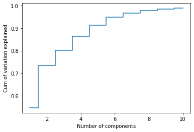

```python
plt.step(list(range(1,11)),np.cumsum(pca.explained_variance_ratio_), where='mid')
plt.ylabel('Cum of variation explained')
plt.xlabel('Number of components')
plt.show()
```

Let's use 6 principal components as they are explaining 95% variance.

```python
pca = PCA(n_components=6)
pca.fit(X)
components = pca.components_
```

```python
# Transform data to these components
Xpca = pca.transform(X)
```

### Step 7: SVM and K-Fold CV

```python
X_train, X_test, y_train, y_test = train_test_split(Xpca,y,test_size=0.3,random_state=random_state)
```

Next, let's train the SVM model.

```python
model = SVC()
```

```python
model.fit(X_train,y_train)
```

```
SVC(C=1.0, cache_size=200, class_weight=None, coef0=0.0,
    decision_function_shape='ovr', degree=3, gamma='auto_deprecated',
    kernel='rbf', max_iter=-1, probability=False, random_state=None,
    shrinking=True, tol=0.001, verbose=False)
```

```python
model.score(X_test,y_test)
```

```
0.9032258064516129
```

For default values, we are getting a score of 90.32% on test set.

Let's use hyperparameter tuning to get best parameters.

```python
grid = GridSearchCV(SVC(), param_grid, verbose=3, cv=2, n_jobs=2, return_train_score=True)
```

```python
grid.fit(X_train,y_train)
```

```
Fitting 2 folds for each of 40 candidates, totalling 80 fits
```

```
[Parallel(n_jobs=2)]: Using backend LokyBackend with 2 concurrent workers.
[Parallel(n_jobs=2)]: Done  65 tasks      | elapsed:    4.8s
[Parallel(n_jobs=2)]: Done  80 out of  80 | elapsed:    8.9s finished
```

```
GridSearchCV(cv=2, error_score='raise-deprecating',
             estimator=SVC(C=1.0, cache_size=200, class_weight=None, coef0=0.0,
                           decision_function_shape='ovr', degree=3,
                           gamma='auto_deprecated', kernel='rbf', max_iter=-1,
                           probability=False, random_state=None, shrinking=True,
                           tol=0.001, verbose=False),
             iid='warn', n_jobs=2,
             param_grid={'C': [1, 10, 100, 1000],
                         'gamma': [0.01, 0.1, 1, 10, 100],
                         'kernel': ['rbf', 'linear']},
             pre_dispatch='2*n_jobs', refit=True, return_train_score=True,
             scoring=None, verbose=3)
```

```python
print(grid.best_params_)
```

```
{'C': 100, 'gamma': 0.01, 'kernel': 'rbf'}
```

```python
model = SVC(C=100,gamma=0.01,kernel="rbf")
```

```python
model.fit(X_train,y_train)
```

```
SVC(C=100, cache_size=200, class_weight=None, coef0=0.0,
    decision_function_shape='ovr', degree=3, gamma=0.01, kernel='rbf',
    max_iter=-1, probability=False, random_state=None, shrinking=True,
    tol=0.001, verbose=False)
```

```python
pred = model.predict(X_test)
```

```python
print(classification_report(y_test,pred))
```

```
              precision    recall  f1-score   support

           0       0.84      0.89      0.86        53
           1       0.95      0.90      0.92       130
           2       0.90      0.95      0.93        65

    accuracy                           0.91       248
   macro avg       0.90      0.91      0.90       248
weighted avg       0.91      0.91      0.91       248
```

```python
model.score(X_test, y_test)
```

```
0.9112903225806451
```

We are able to get an accuracy of 91.13% by using principal components in SVM.

Next, let's perform K-Fold CV.

```python
scores = cross_val_score(model,Xpca,y,cv=5)
```

```python
print("Accuracy: %0.2f (+/- %0.2f)" % (scores.mean(), scores.std() * 2))
```

```
Accuracy: 0.93 (+/- 0.04)
```

We were able to get an accuracy of 93% $\pm$ 4%.

### Step 8: Comparison

As we saw, without using principal components, we were only able to get an accuracy of 71.77% on test set and a K-Fold CV score of 75%, whereas, with 6 principal components, we were able to get an accuracy of 91.13% on test set and a K-Fold CV score of 93%.

This shows that PCA is very powerful at transforming data to components which can explain maximum variance (95% variance was explained by the 6 components). While this definitely shows how useful a tool PCA is, it also removes the explainability part from the components.